RELIABILITY  
/VARIABLES=S2_R2 S1_R2 S1_R1 S2_R1  
/SCALE('ALL VARIABLES') ALL  
/MODEL=ALPHA  
/STATISTICS=CORR ANOVA  
/SUMMARY=CORR  
/ICC=MODEL(MIXED) TYPE(ABSOLUTE) CIN=95 TESTVAL=0.

# **Reliability**

NotesNotes, table, 0 levels of column headers and 2 levels of row headers, table with 3 columns and 15 rows

| Output Created |  | 15-APR-2019 23:50:10 |
| --- | --- | --- |
| Comments |  |  |
| Input | Data | Z:\Documents\GitHub\STISIM-Task-Analysis\SPSS Results\Wideform Template.sav |
|  | Active Dataset | DataSet1 |
|  | Filter | <none> |
|  | Weight | <none> |
|  | Split File | <none> |
|  | N of Rows in Working Data File | 14 |
|  | Matrix Input |  |
| Missing Value Handling | Definition of Missing | User-defined missing values are treated as missing. |
|  | Cases Used | Statistics are based on all cases with valid data for all variables in the procedure. |
| Syntax |  | RELIABILITY /VARIABLES=S2_R2 S1_R2 S1_R1 S2_R1 /SCALE('ALL VARIABLES') ALL /MODEL=ALPHA /STATISTICS=CORR ANOVA /SUMMARY=CORR /ICC=MODEL(MIXED) TYPE(ABSOLUTE) CIN=95 TESTVAL=0. |
| Resources | Processor Time | 00:00:00.00 |
|  | Elapsed Time | 00:00:00.01 |

# **Scale: ALL VARIABLES**

Case Processing SummaryCase Processing Summary, table, 1 levels of column headers and 2 levels of row headers, table with 4 columns and 6 rows

|  |  | N | % |
| --- | --- | --- | --- |
| Cases | Valid | 14 | 100.0 |
|  | Excluded<sup>a</sup> | 0 | .0 |
|  | Total | 14 | 100.0 |

a. Listwise deletion based on all variables in the procedure.

Reliability StatisticsReliability Statistics, table, 1 levels of column headers and 0 levels of row headers, table with 3 columns and 3 rows

| Cronbach's Alpha | Cronbach's Alpha Based on Standardized Items | N of Items |
| --- | --- | --- |
| .883 | .891 | 4 |

Inter-Item Correlation MatrixInter-Item Correlation Matrix, table, 1 levels of column headers and 1 levels of row headers, table with 5 columns and 6 rows

|  | S2_R2 | S1_R2 | S1_R1 | S2_R1 |
| --- | --- | --- | --- | --- |
| S2_R2 | 1.000 | .446 | .640 | .850 |
| S1_R2 | .446 | 1.000 | .886 | .481 |
| S1_R1 | .640 | .886 | 1.000 | .721 |
| S2_R1 | .850 | .481 | .721 | 1.000 |

Summary Item StatisticsSummary Item Statistics, table, 1 levels of column headers and 1 levels of row headers, table with 8 columns and 3 rows

|  | Mean | Minimum | Maximum | Range | Maximum / Minimum | Variance | N of Items |
| --- | --- | --- | --- | --- | --- | --- | --- |
| Inter-Item Correlations | .671 | .446 | .886 | .440 | 1.987 | .031 | 4 |

ANOVAANOVA, table, 1 levels of column headers and 2 levels of row headers, table with 7 columns and 8 rows

|  |  | Sum of Squares | df | Mean Square | F | Sig |
| --- | --- | --- | --- | --- | --- | --- |
| Between People |  | 92.467 | 13 | 7.113 |  |  |
| Within People | Between Items | 2.555 | 3 | .852 | 1.021 | .394 |
|  | Residual | 32.527 | 39 | .834 |  |  |
|  | Total | 35.082 | 42 | .835 |  |  |
| Total |  | 127.549 | 55 | 2.319 |  |  |

Grand Mean = 98.4578

Intraclass Correlation CoefficientIntraclass Correlation Coefficient, table, 2 levels of column headers and 1 levels of row headers, table with 8 columns and 9 rows

|  | Intraclass Correlation<sup>b</sup> | 95% Confidence Interval |  | F Test with True Value 0 |  |  |  |
| --- | --- | --- | --- | --- | --- | --- | --- |
|  |  | Lower Bound | Upper Bound | Value | df1 | df2 | Sig |
| Single Measures | .653<sup>a</sup> | .413 | .850 | 8.528 | 13 | 39 | .000 |
| Average Measures | .883<sup>c</sup> | .738 | .958 | 8.528 | 13 | 39 | .000 |

Two-way mixed effects model where people effects are random and measures effects are fixed.  
a. The estimator is the same, whether the interaction effect is present or not.  
b. Type A intraclass correlation coefficients using an absolute agreement definition.  
c. This estimate is computed assuming the interaction effect is absent, because it is not estimable otherwise.

CORRELATIONS  
/VARIABLES=S2_R1 S2_R2 S1_R1 S1_R2  
/PRINT=TWOTAIL NOSIG  
/MISSING=PAIRWISE.

# **Correlations**

NotesNotes, table, 0 levels of column headers and 2 levels of row headers, table with 3 columns and 14 rows

| Output Created |  | 15-APR-2019 23:50:10 |
| --- | --- | --- |
| Comments |  |  |
| Input | Data | Z:\Documents\GitHub\STISIM-Task-Analysis\SPSS Results\Wideform Template.sav |
|  | Active Dataset | DataSet1 |
|  | Filter | <none> |
|  | Weight | <none> |
|  | Split File | <none> |
|  | N of Rows in Working Data File | 14 |
| Missing Value Handling | Definition of Missing | User-defined missing values are treated as missing. |
|  | Cases Used | Statistics for each pair of variables are based on all the cases with valid data for that pair. |
| Syntax |  | CORRELATIONS /VARIABLES=S2_R1 S2_R2 S1_R1 S1_R2 /PRINT=TWOTAIL NOSIG /MISSING=PAIRWISE. |
| Resources | Processor Time | 00:00:00.00 |
|  | Elapsed Time | 00:00:00.01 |

CorrelationsCorrelations, table, 1 levels of column headers and 2 levels of row headers, table with 6 columns and 16 rows

|  |  | S2_R1 | S2_R2 | S1_R1 | S1_R2 |
| --- | --- | --- | --- | --- | --- |
| S2_R1 | Pearson Correlation | 1 | .850** | .721** | .481 |
|  | Sig. (2-tailed) |  | .000 | .004 | .082 |
|  | N | 14 | 14 | 14 | 14 |
| S2_R2 | Pearson Correlation | .850** | 1 | .640* | .446 |
|  | Sig. (2-tailed) | .000 |  | .014 | .110 |
|  | N | 14 | 14 | 14 | 14 |
| S1_R1 | Pearson Correlation | .721** | .640* | 1 | .886** |
|  | Sig. (2-tailed) | .004 | .014 |  | .000 |
|  | N | 14 | 14 | 14 | 14 |
| S1_R2 | Pearson Correlation | .481 | .446 | .886** | 1 |
|  | Sig. (2-tailed) | .082 | .110 | .000 |  |
|  | N | 14 | 14 | 14 | 14 |

**. Correlation is significant at the 0.01 level (2-tailed).  
*. Correlation is significant at the 0.05 level (2-tailed).

RELIABILITY  
/VARIABLES=S1_R1 S1_R2  
/SCALE('ALL VARIABLES') ALL  
/MODEL=ALPHA  
/STATISTICS=CORR ANOVA  
/ICC=MODEL(MIXED) TYPE(ABSOLUTE) CIN=95 TESTVAL=0.

# **Reliability**

NotesNotes, table, 0 levels of column headers and 2 levels of row headers, table with 3 columns and 15 rows

| Output Created |  | 15-APR-2019 23:50:10 |
| --- | --- | --- |
| Comments |  |  |
| Input | Data | Z:\Documents\GitHub\STISIM-Task-Analysis\SPSS Results\Wideform Template.sav |
|  | Active Dataset | DataSet1 |
|  | Filter | <none> |
|  | Weight | <none> |
|  | Split File | <none> |
|  | N of Rows in Working Data File | 14 |
|  | Matrix Input |  |
| Missing Value Handling | Definition of Missing | User-defined missing values are treated as missing. |
|  | Cases Used | Statistics are based on all cases with valid data for all variables in the procedure. |
| Syntax |  | RELIABILITY /VARIABLES=S1_R1 S1_R2 /SCALE('ALL VARIABLES') ALL /MODEL=ALPHA /STATISTICS=CORR ANOVA /ICC=MODEL(MIXED) TYPE(ABSOLUTE) CIN=95 TESTVAL=0. |
| Resources | Processor Time | 00:00:00.02 |
|  | Elapsed Time | 00:00:00.01 |

# **Scale: ALL VARIABLES**

Case Processing SummaryCase Processing Summary, table, 1 levels of column headers and 2 levels of row headers, table with 4 columns and 6 rows

|  |  | N | % |
| --- | --- | --- | --- |
| Cases | Valid | 14 | 100.0 |
|  | Excluded<sup>a</sup> | 0 | .0 |
|  | Total | 14 | 100.0 |

a. Listwise deletion based on all variables in the procedure.

Reliability StatisticsReliability Statistics, table, 1 levels of column headers and 0 levels of row headers, table with 3 columns and 3 rows

| Cronbach's Alpha | Cronbach's Alpha Based on Standardized Items | N of Items |
| --- | --- | --- |
| .924 | .940 | 2 |

Inter-Item Correlation MatrixInter-Item Correlation Matrix, table, 1 levels of column headers and 1 levels of row headers, table with 3 columns and 4 rows

|  | S1_R1 | S1_R2 |
| --- | --- | --- |
| S1_R1 | 1.000 | .886 |
| S1_R2 | .886 | 1.000 |

ANOVAANOVA, table, 1 levels of column headers and 2 levels of row headers, table with 7 columns and 8 rows

|  |  | Sum of Squares | df | Mean Square | F | Sig |
| --- | --- | --- | --- | --- | --- | --- |
| Between People |  | 64.057 | 13 | 4.927 |  |  |
| Within People | Between Items | .003 | 1 | .003 | .009 | .927 |
|  | Residual | 4.840 | 13 | .372 |  |  |
|  | Total | 4.844 | 14 | .346 |  |  |
| Total |  | 68.901 | 27 | 2.552 |  |  |

Grand Mean = 98.2785

Intraclass Correlation CoefficientIntraclass Correlation Coefficient, table, 2 levels of column headers and 1 levels of row headers, table with 8 columns and 9 rows

|  | Intraclass Correlation<sup>b</sup> | 95% Confidence Interval |  | F Test with True Value 0 |  |  |  |
| --- | --- | --- | --- | --- | --- | --- | --- |
|  |  | Lower Bound | Upper Bound | Value | df1 | df2 | Sig |
| Single Measures | .868<sup>a</sup> | .636 | .956 | 13.234 | 13 | 13 | .000 |
| Average Measures | .929<sup>c</sup> | .778 | .977 | 13.234 | 13 | 13 | .000 |

Two-way mixed effects model where people effects are random and measures effects are fixed.  
a. The estimator is the same, whether the interaction effect is present or not.  
b. Type A intraclass correlation coefficients using an absolute agreement definition.  
c. This estimate is computed assuming the interaction effect is absent, because it is not estimable otherwise.

CORRELATIONS  
/VARIABLES=S1_R1 S1_R2  
/PRINT=TWOTAIL NOSIG  
/MISSING=PAIRWISE.

# **Correlations**

NotesNotes, table, 0 levels of column headers and 2 levels of row headers, table with 3 columns and 14 rows

| Output Created |  | 15-APR-2019 23:50:10 |
| --- | --- | --- |
| Comments |  |  |
| Input | Data | Z:\Documents\GitHub\STISIM-Task-Analysis\SPSS Results\Wideform Template.sav |
|  | Active Dataset | DataSet1 |
|  | Filter | <none> |
|  | Weight | <none> |
|  | Split File | <none> |
|  | N of Rows in Working Data File | 14 |
| Missing Value Handling | Definition of Missing | User-defined missing values are treated as missing. |
|  | Cases Used | Statistics for each pair of variables are based on all the cases with valid data for that pair. |
| Syntax |  | CORRELATIONS /VARIABLES=S1_R1 S1_R2 /PRINT=TWOTAIL NOSIG /MISSING=PAIRWISE. |
| Resources | Processor Time | 00:00:00.00 |
|  | Elapsed Time | 00:00:00.01 |

CorrelationsCorrelations, table, 1 levels of column headers and 2 levels of row headers, table with 4 columns and 9 rows

|  |  | S1_R1 | S1_R2 |
| --- | --- | --- | --- |
| S1_R1 | Pearson Correlation | 1 | .886** |
|  | Sig. (2-tailed) |  | .000 |
|  | N | 14 | 14 |
| S1_R2 | Pearson Correlation | .886** | 1 |
|  | Sig. (2-tailed) | .000 |  |
|  | N | 14 | 14 |

**. Correlation is significant at the 0.01 level (2-tailed).

RELIABILITY  
/VARIABLES=S2_R1 S2_R2  
/SCALE('ALL VARIABLES') ALL  
/MODEL=ALPHA  
/STATISTICS=CORR ANOVA  
/ICC=MODEL(MIXED) TYPE(ABSOLUTE) CIN=95 TESTVAL=0.

# **Reliability**

NotesNotes, table, 0 levels of column headers and 2 levels of row headers, table with 3 columns and 15 rows

| Output Created |  | 15-APR-2019 23:50:10 |
| --- | --- | --- |
| Comments |  |  |
| Input | Data | Z:\Documents\GitHub\STISIM-Task-Analysis\SPSS Results\Wideform Template.sav |
|  | Active Dataset | DataSet1 |
|  | Filter | <none> |
|  | Weight | <none> |
|  | Split File | <none> |
|  | N of Rows in Working Data File | 14 |
|  | Matrix Input |  |
| Missing Value Handling | Definition of Missing | User-defined missing values are treated as missing. |
|  | Cases Used | Statistics are based on all cases with valid data for all variables in the procedure. |
| Syntax |  | RELIABILITY /VARIABLES=S2_R1 S2_R2 /SCALE('ALL VARIABLES') ALL /MODEL=ALPHA /STATISTICS=CORR ANOVA /ICC=MODEL(MIXED) TYPE(ABSOLUTE) CIN=95 TESTVAL=0. |
| Resources | Processor Time | 00:00:00.00 |
|  | Elapsed Time | 00:00:00.00 |

# **Scale: ALL VARIABLES**

Case Processing SummaryCase Processing Summary, table, 1 levels of column headers and 2 levels of row headers, table with 4 columns and 6 rows

|  |  | N | % |
| --- | --- | --- | --- |
| Cases | Valid | 14 | 100.0 |
|  | Excluded<sup>a</sup> | 0 | .0 |
|  | Total | 14 | 100.0 |

a. Listwise deletion based on all variables in the procedure.

Reliability StatisticsReliability Statistics, table, 1 levels of column headers and 0 levels of row headers, table with 3 columns and 3 rows

| Cronbach's Alpha | Cronbach's Alpha Based on Standardized Items | N of Items |
| --- | --- | --- |
| .919 | .919 | 2 |

Inter-Item Correlation MatrixInter-Item Correlation Matrix, table, 1 levels of column headers and 1 levels of row headers, table with 3 columns and 4 rows

|  | S2_R1 | S2_R2 |
| --- | --- | --- |
| S2_R1 | 1.000 | .850 |
| S2_R2 | .850 | 1.000 |

ANOVAANOVA, table, 1 levels of column headers and 2 levels of row headers, table with 7 columns and 8 rows

|  |  | Sum of Squares | df | Mean Square | F | Sig |
| --- | --- | --- | --- | --- | --- | --- |
| Between People |  | 51.881 | 13 | 3.991 |  |  |
| Within People | Between Items | .751 | 1 | .751 | 2.316 | .152 |
|  | Residual | 4.216 | 13 | .324 |  |  |
|  | Total | 4.967 | 14 | .355 |  |  |
| Total |  | 56.848 | 27 | 2.105 |  |  |

Grand Mean = 98.6371

Intraclass Correlation CoefficientIntraclass Correlation Coefficient, table, 2 levels of column headers and 1 levels of row headers, table with 8 columns and 9 rows

|  | Intraclass Correlation<sup>b</sup> | 95% Confidence Interval |  | F Test with True Value 0 |  |  |  |
| --- | --- | --- | --- | --- | --- | --- | --- |
|  |  | Lower Bound | Upper Bound | Value | df1 | df2 | Sig |
| Single Measures | .838<sup>a</sup> | .575 | .945 | 12.305 | 13 | 13 | .000 |
| Average Measures | .912<sup>c</sup> | .730 | .971 | 12.305 | 13 | 13 | .000 |

Two-way mixed effects model where people effects are random and measures effects are fixed.  
a. The estimator is the same, whether the interaction effect is present or not.  
b. Type A intraclass correlation coefficients using an absolute agreement definition.  
c. This estimate is computed assuming the interaction effect is absent, because it is not estimable otherwise.

CORRELATIONS  
/VARIABLES=S2_R1 S2_R2  
/PRINT=TWOTAIL NOSIG  
/MISSING=PAIRWISE.

# **Correlations**

NotesNotes, table, 0 levels of column headers and 2 levels of row headers, table with 3 columns and 14 rows

| Output Created |  | 15-APR-2019 23:50:10 |
| --- | --- | --- |
| Comments |  |  |
| Input | Data | Z:\Documents\GitHub\STISIM-Task-Analysis\SPSS Results\Wideform Template.sav |
|  | Active Dataset | DataSet1 |
|  | Filter | <none> |
|  | Weight | <none> |
|  | Split File | <none> |
|  | N of Rows in Working Data File | 14 |
| Missing Value Handling | Definition of Missing | User-defined missing values are treated as missing. |
|  | Cases Used | Statistics for each pair of variables are based on all the cases with valid data for that pair. |
| Syntax |  | CORRELATIONS /VARIABLES=S2_R1 S2_R2 /PRINT=TWOTAIL NOSIG /MISSING=PAIRWISE. |
| Resources | Processor Time | 00:00:00.02 |
|  | Elapsed Time | 00:00:00.01 |

CorrelationsCorrelations, table, 1 levels of column headers and 2 levels of row headers, table with 4 columns and 9 rows

|  |  | S2_R1 | S2_R2 |
| --- | --- | --- | --- |
| S2_R1 | Pearson Correlation | 1 | .850** |
|  | Sig. (2-tailed) |  | .000 |
|  | N | 14 | 14 |
| S2_R2 | Pearson Correlation | .850** | 1 |
|  | Sig. (2-tailed) | .000 |  |
|  | N | 14 | 14 |

**. Correlation is significant at the 0.01 level (2-tailed).

RELIABILITY  
/VARIABLES=S2_R2 S1_R2  
/SCALE('ALL VARIABLES') ALL  
/MODEL=ALPHA  
/STATISTICS=CORR ANOVA  
/SUMMARY=CORR  
/ICC=MODEL(MIXED) TYPE(ABSOLUTE) CIN=95 TESTVAL=0.

# **Reliability**

NotesNotes, table, 0 levels of column headers and 2 levels of row headers, table with 3 columns and 15 rows

| Output Created |  | 15-APR-2019 23:50:10 |
| --- | --- | --- |
| Comments |  |  |
| Input | Data | Z:\Documents\GitHub\STISIM-Task-Analysis\SPSS Results\Wideform Template.sav |
|  | Active Dataset | DataSet1 |
|  | Filter | <none> |
|  | Weight | <none> |
|  | Split File | <none> |
|  | N of Rows in Working Data File | 14 |
|  | Matrix Input |  |
| Missing Value Handling | Definition of Missing | User-defined missing values are treated as missing. |
|  | Cases Used | Statistics are based on all cases with valid data for all variables in the procedure. |
| Syntax |  | RELIABILITY /VARIABLES=S2_R2 S1_R2 /SCALE('ALL VARIABLES') ALL /MODEL=ALPHA /STATISTICS=CORR ANOVA /SUMMARY=CORR /ICC=MODEL(MIXED) TYPE(ABSOLUTE) CIN=95 TESTVAL=0. |
| Resources | Processor Time | 00:00:00.00 |
|  | Elapsed Time | 00:00:00.00 |

# **Scale: ALL VARIABLES**

Case Processing SummaryCase Processing Summary, table, 1 levels of column headers and 2 levels of row headers, table with 4 columns and 6 rows

|  |  | N | % |
| --- | --- | --- | --- |
| Cases | Valid | 14 | 100.0 |
|  | Excluded<sup>a</sup> | 0 | .0 |
|  | Total | 14 | 100.0 |

a. Listwise deletion based on all variables in the procedure.

Reliability StatisticsReliability Statistics, table, 1 levels of column headers and 0 levels of row headers, table with 3 columns and 3 rows

| Cronbach's Alpha | Cronbach's Alpha Based on Standardized Items | N of Items |
| --- | --- | --- |
| .606 | .617 | 2 |

Inter-Item Correlation MatrixInter-Item Correlation Matrix, table, 1 levels of column headers and 1 levels of row headers, table with 3 columns and 4 rows

|  | S2_R2 | S1_R2 |
| --- | --- | --- |
| S2_R2 | 1.000 | .446 |
| S1_R2 | .446 | 1.000 |

Summary Item StatisticsSummary Item Statistics, table, 1 levels of column headers and 1 levels of row headers, table with 8 columns and 3 rows

|  | Mean | Minimum | Maximum | Range | Maximum / Minimum | Variance | N of Items |
| --- | --- | --- | --- | --- | --- | --- | --- |
| Inter-Item Correlations | .446 | .446 | .446 | .000 | 1.000 | .000 | 2 |

ANOVAANOVA, table, 1 levels of column headers and 2 levels of row headers, table with 7 columns and 8 rows

|  |  | Sum of Squares | df | Mean Square | F | Sig |
| --- | --- | --- | --- | --- | --- | --- |
| Between People |  | 50.079 | 13 | 3.852 |  |  |
| Within People | Between Items | 1.990 | 1 | 1.990 | 1.310 | .273 |
|  | Residual | 19.745 | 13 | 1.519 |  |  |
|  | Total | 21.735 | 14 | 1.553 |  |  |
| Total |  | 71.814 | 27 | 2.660 |  |  |

Grand Mean = 98.5343

Intraclass Correlation CoefficientIntraclass Correlation Coefficient, table, 2 levels of column headers and 1 levels of row headers, table with 8 columns and 9 rows

|  | Intraclass Correlation<sup>b</sup> | 95% Confidence Interval |  | F Test with True Value 0 |  |  |  |
| --- | --- | --- | --- | --- | --- | --- | --- |
|  |  | Lower Bound | Upper Bound | Value | df1 | df2 | Sig |
| Single Measures | .429<sup>a</sup> | -.085 | .769 | 2.536 | 13 | 13 | .053 |
| Average Measures | .600<sup>c</sup> | -.185 | .870 | 2.536 | 13 | 13 | .053 |

Two-way mixed effects model where people effects are random and measures effects are fixed.  
a. The estimator is the same, whether the interaction effect is present or not.  
b. Type A intraclass correlation coefficients using an absolute agreement definition.  
c. This estimate is computed assuming the interaction effect is absent, because it is not estimable otherwise.

CORRELATIONS  
/VARIABLES=S2_R2 S1_R2  
/PRINT=TWOTAIL NOSIG  
/MISSING=PAIRWISE.

# **Correlations**

NotesNotes, table, 0 levels of column headers and 2 levels of row headers, table with 3 columns and 14 rows

| Output Created |  | 15-APR-2019 23:50:10 |
| --- | --- | --- |
| Comments |  |  |
| Input | Data | Z:\Documents\GitHub\STISIM-Task-Analysis\SPSS Results\Wideform Template.sav |
|  | Active Dataset | DataSet1 |
|  | Filter | <none> |
|  | Weight | <none> |
|  | Split File | <none> |
|  | N of Rows in Working Data File | 14 |
| Missing Value Handling | Definition of Missing | User-defined missing values are treated as missing. |
|  | Cases Used | Statistics for each pair of variables are based on all the cases with valid data for that pair. |
| Syntax |  | CORRELATIONS /VARIABLES=S2_R2 S1_R2 /PRINT=TWOTAIL NOSIG /MISSING=PAIRWISE. |
| Resources | Processor Time | 00:00:00.00 |
|  | Elapsed Time | 00:00:00.01 |

CorrelationsCorrelations, table, 1 levels of column headers and 2 levels of row headers, table with 4 columns and 8 rows

|  |  | S2_R2 | S1_R2 |
| --- | --- | --- | --- |
| S2_R2 | Pearson Correlation | 1 | .446 |
|  | Sig. (2-tailed) |  | .110 |
|  | N | 14 | 14 |
| S1_R2 | Pearson Correlation | .446 | 1 |
|  | Sig. (2-tailed) | .110 |  |
|  | N | 14 | 14 |

* Encoding: UTF-8.  
EXAMINE VARIABLES=S1_R1 S1_R2 S2_R1 S2_R2  
/PLOT BOXPLOT NPPLOT  
/COMPARE GROUPS  
/STATISTICS NONE  
/CINTERVAL 95  
/MISSING LISTWISE  
/NOTOTAL.

# **Explore**

NotesNotes, table, 0 levels of column headers and 2 levels of row headers, table with 3 columns and 14 rows

| Output Created |  | 15-APR-2019 23:50:28 |
| --- | --- | --- |
| Comments |  |  |
| Input | Data | Z:\Documents\GitHub\STISIM-Task-Analysis\SPSS Results\Wideform Template.sav |
|  | Active Dataset | DataSet1 |
|  | Filter | <none> |
|  | Weight | <none> |
|  | Split File | <none> |
|  | N of Rows in Working Data File | 14 |
| Missing Value Handling | Definition of Missing | User-defined missing values for dependent variables are treated as missing. |
|  | Cases Used | Statistics are based on cases with no missing values for any dependent variable or factor used. |
| Syntax |  | EXAMINE VARIABLES=S1_R1 S1_R2 S2_R1 S2_R2 /PLOT BOXPLOT NPPLOT /COMPARE GROUPS /STATISTICS NONE /CINTERVAL 95 /MISSING LISTWISE /NOTOTAL. |
| Resources | Processor Time | 00:00:02.61 |
|  | Elapsed Time | 00:00:02.32 |

Case Processing SummaryCase Processing Summary, table, 3 levels of column headers and 1 levels of row headers, table with 7 columns and 8 rows

|  | Cases |  |  |  |  |  |
| --- | --- | --- | --- | --- | --- | --- |
|  | Valid |  | Missing |  | Total |  |
|  | N | Percent | N | Percent | N | Percent |
| S1_R1 | 14 | 100.0% | 0 | 0.0% | 14 | 100.0% |
| S1_R2 | 14 | 100.0% | 0 | 0.0% | 14 | 100.0% |
| S2_R1 | 14 | 100.0% | 0 | 0.0% | 14 | 100.0% |
| S2_R2 | 14 | 100.0% | 0 | 0.0% | 14 | 100.0% |

Tests of NormalityTests of Normality, table, 2 levels of column headers and 1 levels of row headers, table with 7 columns and 9 rows

|  | Kolmogorov-Smirnov<sup>a</sup> |  |  | Shapiro-Wilk |  |  |
| --- | --- | --- | --- | --- | --- | --- |
|  | Statistic | df | Sig. | Statistic | df | Sig. |
| S1_R1 | .182 | 14 | .200* | .906 | 14 | .140 |
| S1_R2 | .267 | 14 | .008 | .756 | 14 | .001 |
| S2_R1 | .131 | 14 | .200* | .964 | 14 | .786 |
| S2_R2 | .123 | 14 | .200* | .954 | 14 | .631 |

*. This is a lower bound of the true significance.  
a. Lilliefors Significance Correction

# **S1_R1**

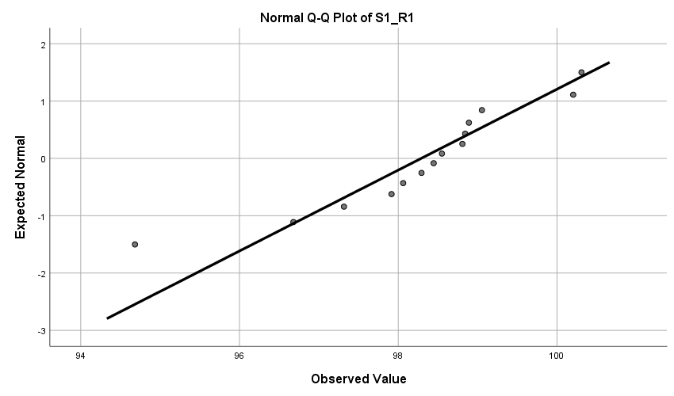

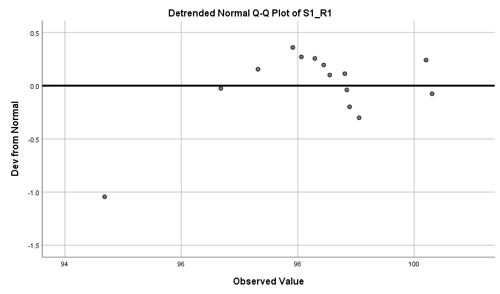

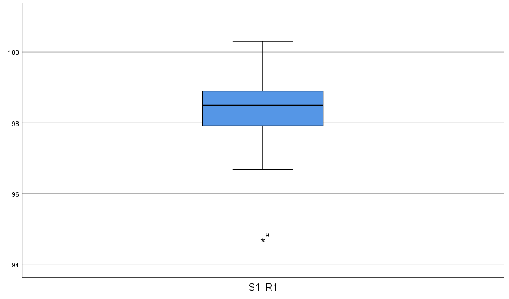

# **S1_R2**

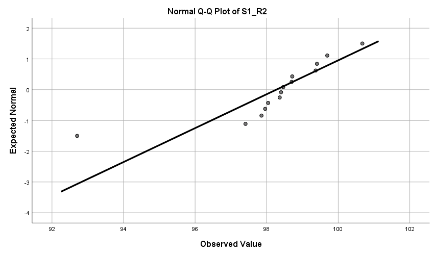

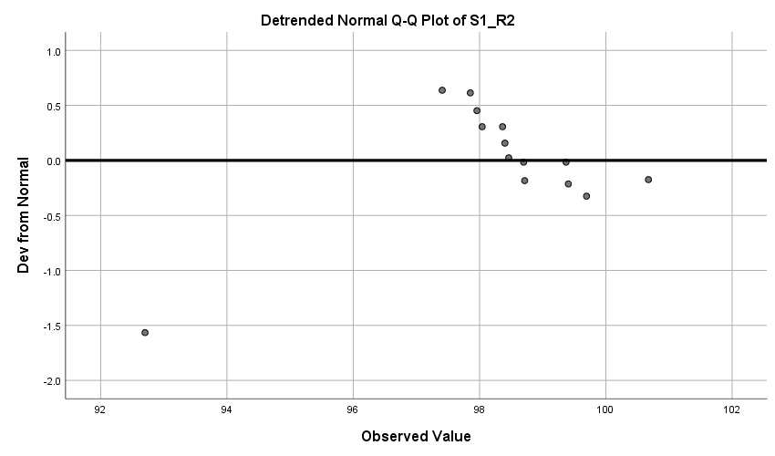

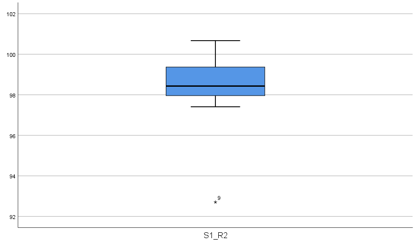

# **S2_R1**

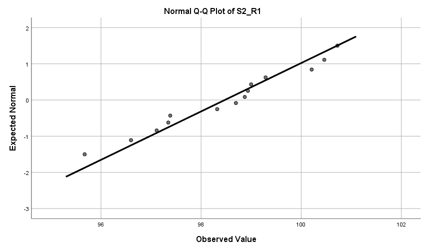

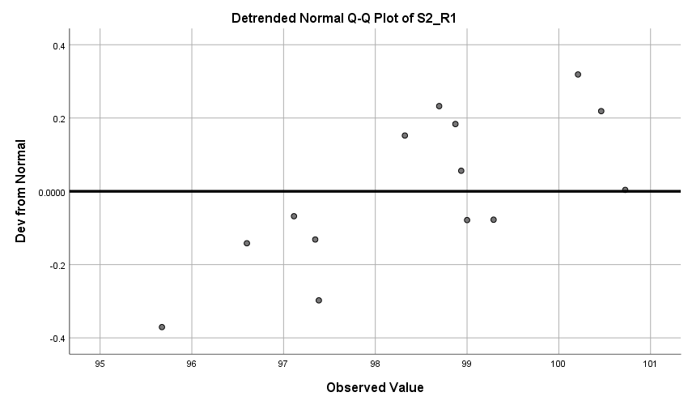

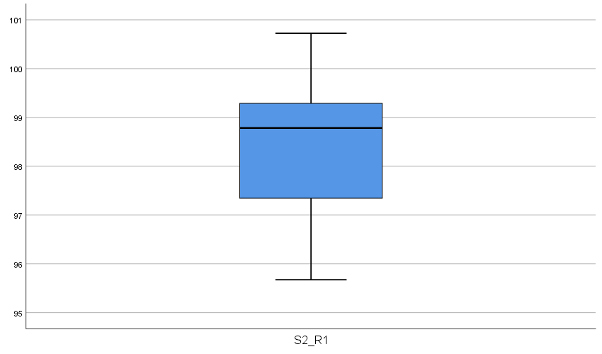

# **S2_R2**

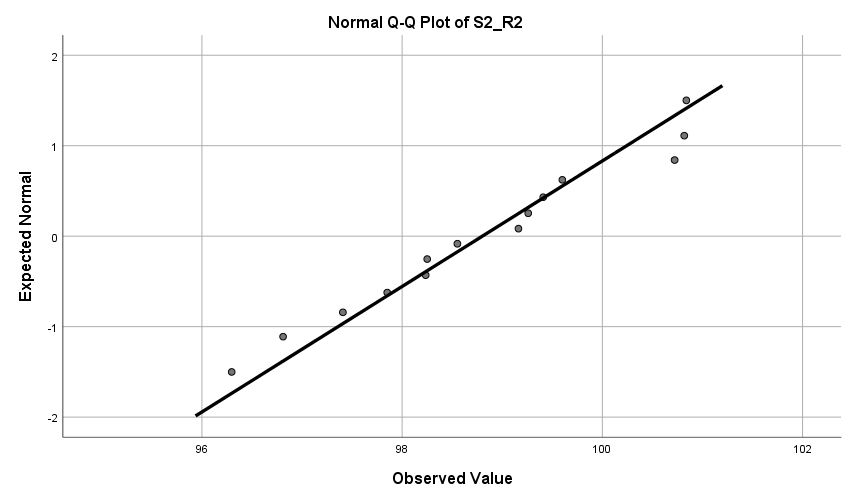

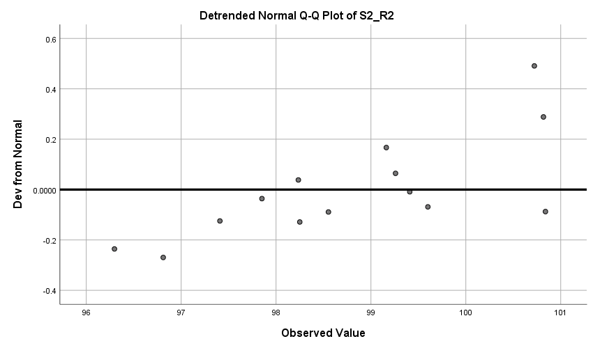

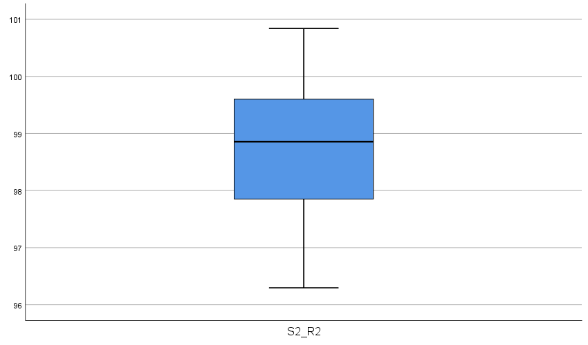

T-TEST PAIRS=S1_R1 S2_R1 S1_R2 WITH S1_R2 S2_R2 S2_R2 (PAIRED)  
/CRITERIA=CI(.9500)  
/MISSING=ANALYSIS.

# **T-Test**

NotesNotes, table, 0 levels of column headers and 2 levels of row headers, table with 3 columns and 14 rows

| Output Created |  | 15-APR-2019 23:50:30 |
| --- | --- | --- |
| Comments |  |  |
| Input | Data | Z:\Documents\GitHub\STISIM-Task-Analysis\SPSS Results\Wideform Template.sav |
|  | Active Dataset | DataSet1 |
|  | Filter | <none> |
|  | Weight | <none> |
|  | Split File | <none> |
|  | N of Rows in Working Data File | 14 |
| Missing Value Handling | Definition of Missing | User defined missing values are treated as missing. |
|  | Cases Used | Statistics for each analysis are based on the cases with no missing or out-of-range data for any variable in the analysis. |
| Syntax |  | T-TEST PAIRS=S1_R1 S2_R1 S1_R2 WITH S1_R2 S2_R2 S2_R2 (PAIRED) /CRITERIA=CI(.9500) /MISSING=ANALYSIS. |
| Resources | Processor Time | 00:00:00.02 |
|  | Elapsed Time | 00:00:00.01 |

Paired Samples StatisticsPaired Samples Statistics, table, 1 levels of column headers and 2 levels of row headers, table with 6 columns and 8 rows

|  |  | Mean | N | Std. Deviation | Std. Error Mean |
| --- | --- | --- | --- | --- | --- |
| Pair 1 | S1_R1 | 98.2894 | 14 | 1.41673 | .37864 |
|  | S1_R2 | 98.2677 | 14 | 1.81458 | .48497 |
| Pair 2 | S2_R1 | 98.4734 | 14 | 1.49558 | .39971 |
|  | S2_R2 | 98.8009 | 14 | 1.44166 | .38530 |
| Pair 3 | S1_R2 | 98.2677 | 14 | 1.81458 | .48497 |
|  | S2_R2 | 98.8009 | 14 | 1.44166 | .38530 |

Paired Samples CorrelationsPaired Samples Correlations, table, 1 levels of column headers and 2 levels of row headers, table with 5 columns and 5 rows

|  |  | N | Correlation | Sig. |
| --- | --- | --- | --- | --- |
| Pair 1 | S1_R1 & S1_R2 | 14 | .886 | .000 |
| Pair 2 | S2_R1 & S2_R2 | 14 | .850 | .000 |
| Pair 3 | S1_R2 & S2_R2 | 14 | .446 | .110 |

Paired Samples TestPaired Samples Test, table, 3 levels of column headers and 2 levels of row headers, table with 10 columns and 7 rows

[output not shown]

COMPUTE logS1_R1=LG10(S1_R1).  
EXECUTE.  
COMPUTE logS1_R2=LG10(S1_R2).  
EXECUTE.  
COMPUTE logS2_R1=LG10(S2_R1).  
EXECUTE.  
COMPUTE logS2_R2=LG10(S2_R2).  
EXECUTE.  
EXAMINE VARIABLES=logS1_R1 logS1_R2 logS2_R1 logS2_R2  
/PLOT NPPLOT  
/STATISTICS NONE  
/CINTERVAL 95  
/MISSING LISTWISE  
/NOTOTAL.

# **Explore**

NotesNotes, table, 0 levels of column headers and 2 levels of row headers, table with 3 columns and 14 rows

| Output Created |  | 15-APR-2019 23:50:31 |
| --- | --- | --- |
| Comments |  |  |
| Input | Data | Z:\Documents\GitHub\STISIM-Task-Analysis\SPSS Results\Wideform Template.sav |
|  | Active Dataset | DataSet1 |
|  | Filter | <none> |
|  | Weight | <none> |
|  | Split File | <none> |
|  | N of Rows in Working Data File | 14 |
| Missing Value Handling | Definition of Missing | User-defined missing values for dependent variables are treated as missing. |
|  | Cases Used | Statistics are based on cases with no missing values for any dependent variable or factor used. |
| Syntax |  | EXAMINE VARIABLES=logS1_R1 logS1_R2 logS2_R1 logS2_R2 /PLOT NPPLOT /STATISTICS NONE /CINTERVAL 95 /MISSING LISTWISE /NOTOTAL. |
| Resources | Processor Time | 00:00:01.66 |
|  | Elapsed Time | 00:00:01.49 |

Case Processing SummaryCase Processing Summary, table, 3 levels of column headers and 1 levels of row headers, table with 7 columns and 8 rows

|  | Cases |  |  |  |  |  |
| --- | --- | --- | --- | --- | --- | --- |
|  | Valid |  | Missing |  | Total |  |
|  | N | Percent | N | Percent | N | Percent |
| logS1_R1 | 14 | 100.0% | 0 | 0.0% | 14 | 100.0% |
| logS1_R2 | 14 | 100.0% | 0 | 0.0% | 14 | 100.0% |
| logS2_R1 | 14 | 100.0% | 0 | 0.0% | 14 | 100.0% |
| logS2_R2 | 14 | 100.0% | 0 | 0.0% | 14 | 100.0% |

Tests of NormalityTests of Normality, table, 2 levels of column headers and 1 levels of row headers, table with 7 columns and 9 rows

|  | Kolmogorov-Smirnov<sup>a</sup> |  |  | Shapiro-Wilk |  |  |
| --- | --- | --- | --- | --- | --- | --- |
|  | Statistic | df | Sig. | Statistic | df | Sig. |
| logS1_R1 | .185 | 14 | .200* | .902 | 14 | .120 |
| logS1_R2 | .272 | 14 | .006 | .745 | 14 | .001 |
| logS2_R1 | .133 | 14 | .200* | .963 | 14 | .776 |
| logS2_R2 | .122 | 14 | .200* | .955 | 14 | .635 |

*. This is a lower bound of the true significance.  
a. Lilliefors Significance Correction

# **logS1_R1**

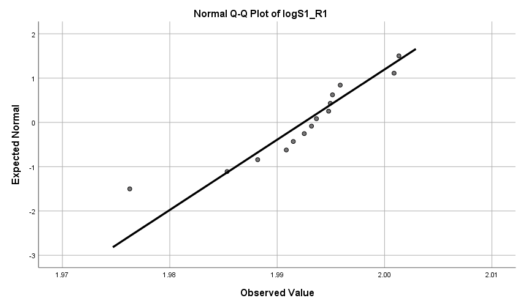

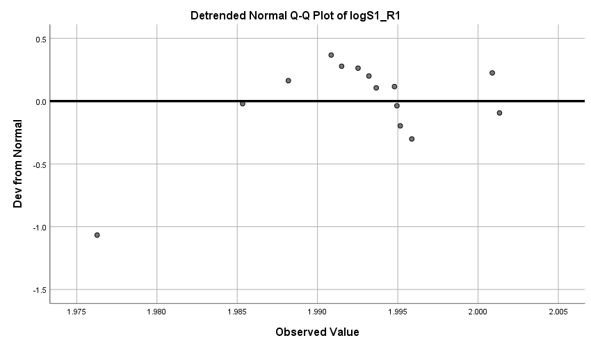

# **logS1_R2**

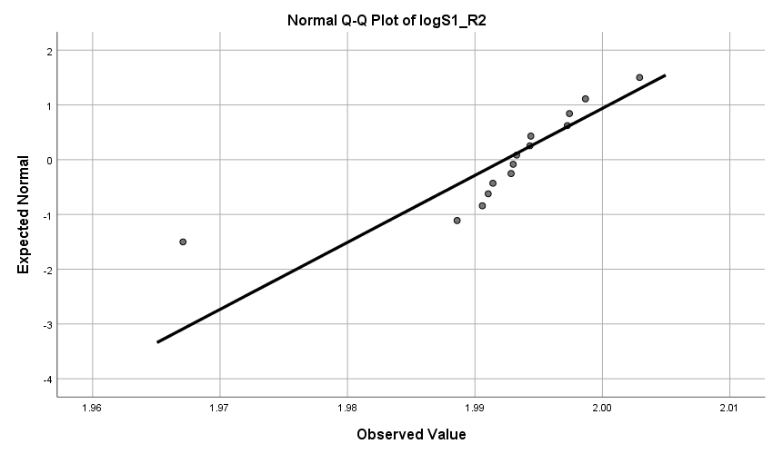

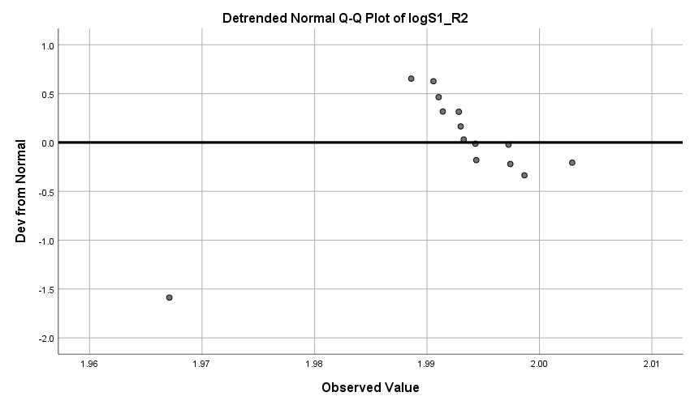

# **logS2_R1**

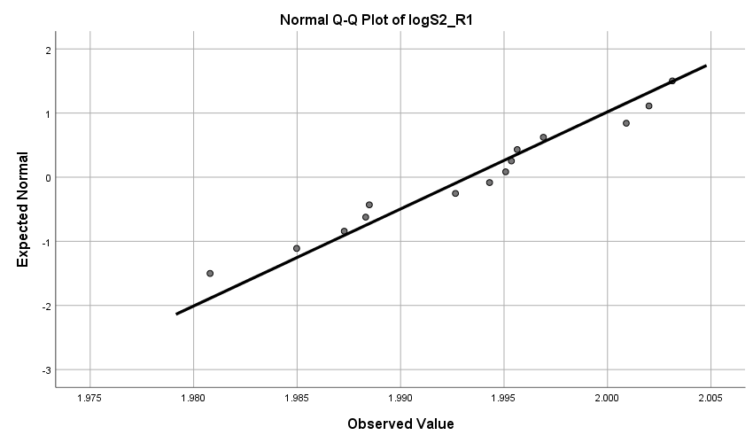

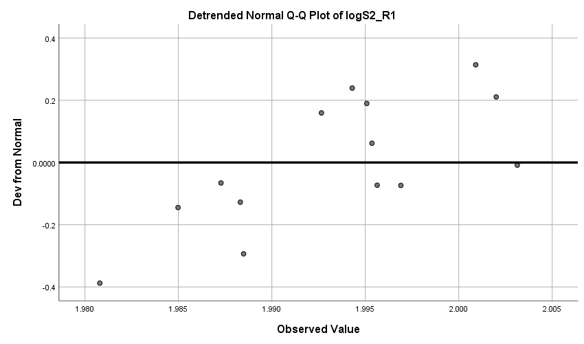

# **logS2_R2**

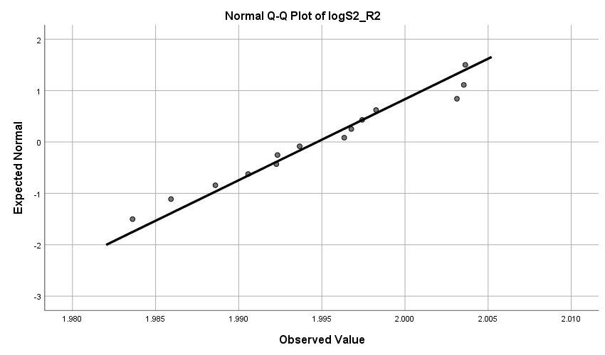

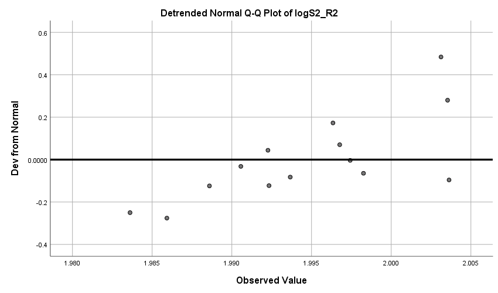

T-TEST PAIRS=logS1_R1 logS2_R1 logS1_R2 WITH logS1_R2 logS2_R2 logS2_R2 (PAIRED)  
/CRITERIA=CI(.9500)  
/MISSING=ANALYSIS.

# **T-Test**

NotesNotes, table, 0 levels of column headers and 2 levels of row headers, table with 3 columns and 14 rows

| Output Created |  | 15-APR-2019 23:50:32 |
| --- | --- | --- |
| Comments |  |  |
| Input | Data | Z:\Documents\GitHub\STISIM-Task-Analysis\SPSS Results\Wideform Template.sav |
|  | Active Dataset | DataSet1 |
|  | Filter | <none> |
|  | Weight | <none> |
|  | Split File | <none> |
|  | N of Rows in Working Data File | 14 |
| Missing Value Handling | Definition of Missing | User defined missing values are treated as missing. |
|  | Cases Used | Statistics for each analysis are based on the cases with no missing or out-of-range data for any variable in the analysis. |
| Syntax |  | T-TEST PAIRS=logS1_R1 logS2_R1 logS1_R2 WITH logS1_R2 logS2_R2 logS2_R2 (PAIRED) /CRITERIA=CI(.9500) /MISSING=ANALYSIS. |
| Resources | Processor Time | 00:00:00.02 |
|  | Elapsed Time | 00:00:00.00 |

Paired Samples StatisticsPaired Samples Statistics, table, 1 levels of column headers and 2 levels of row headers, table with 6 columns and 8 rows

|  |  | Mean | N | Std. Deviation | Std. Error Mean |
| --- | --- | --- | --- | --- | --- |
| Pair 1 | logS1_R1 | 1.9925 | 14 | .00631 | .00169 |
|  | logS1_R2 | 1.9923 | 14 | .00817 | .00218 |
| Pair 2 | logS2_R1 | 1.9933 | 14 | .00661 | .00177 |
|  | logS2_R2 | 1.9947 | 14 | .00634 | .00169 |
| Pair 3 | logS1_R2 | 1.9923 | 14 | .00817 | .00218 |
|  | logS2_R2 | 1.9947 | 14 | .00634 | .00169 |

Paired Samples CorrelationsPaired Samples Correlations, table, 1 levels of column headers and 2 levels of row headers, table with 5 columns and 5 rows

|  |  | N | Correlation | Sig. |
| --- | --- | --- | --- | --- |
| Pair 1 | logS1_R1 & logS1_R2 | 14 | .888 | .000 |
| Pair 2 | logS2_R1 & logS2_R2 | 14 | .849 | .000 |
| Pair 3 | logS1_R2 & logS2_R2 | 14 | .437 | .118 |

Paired Samples TestPaired Samples Test, table, 3 levels of column headers and 2 levels of row headers, table with 10 columns and 7 rows

[output not shown]

*Nonparametric Tests: Related Samples.  
NPTESTS  
/RELATED TEST(S1_R1 S1_R2) WILCOXON  
/MISSING SCOPE=ANALYSIS USERMISSING=EXCLUDE  
/CRITERIA ALPHA=0.05 CILEVEL=95.

# **Nonparametric Tests**

NotesNotes, table, 0 levels of column headers and 2 levels of row headers, table with 3 columns and 12 rows

| Output Created |  | 15-APR-2019 23:50:32 |
| --- | --- | --- |
| Comments |  |  |
| Input | Data | Z:\Documents\GitHub\STISIM-Task-Analysis\SPSS Results\Wideform Template.sav |
|  | Active Dataset | DataSet1 |
|  | Filter | <none> |
|  | Weight | <none> |
|  | Split File | <none> |
|  | N of Rows in Working Data File | 14 |
| Syntax |  | NPTESTS /RELATED TEST(S1_R1 S1_R2) WILCOXON /MISSING SCOPE=ANALYSIS USERMISSING=EXCLUDE /CRITERIA ALPHA=0.05 CILEVEL=95. |
| Resources | Processor Time | 00:00:00.14 |
|  | Elapsed Time | 00:00:00.09 |

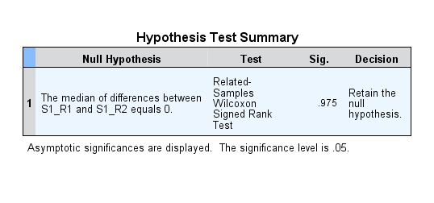

*Nonparametric Tests: Related Samples.  
NPTESTS  
/RELATED TEST(S2_R1 S2_R2) WILCOXON  
/MISSING SCOPE=ANALYSIS USERMISSING=EXCLUDE  
/CRITERIA ALPHA=0.05 CILEVEL=95.

# **Nonparametric Tests**

NotesNotes, table, 0 levels of column headers and 2 levels of row headers, table with 3 columns and 12 rows

| Output Created |  | 15-APR-2019 23:50:32 |
| --- | --- | --- |
| Comments |  |  |
| Input | Data | Z:\Documents\GitHub\STISIM-Task-Analysis\SPSS Results\Wideform Template.sav |
|  | Active Dataset | DataSet1 |
|  | Filter | <none> |
|  | Weight | <none> |
|  | Split File | <none> |
|  | N of Rows in Working Data File | 14 |
| Syntax |  | NPTESTS /RELATED TEST(S2_R1 S2_R2) WILCOXON /MISSING SCOPE=ANALYSIS USERMISSING=EXCLUDE /CRITERIA ALPHA=0.05 CILEVEL=95. |
| Resources | Processor Time | 00:00:00.13 |
|  | Elapsed Time | 00:00:00.09 |

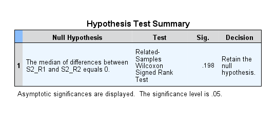

*Nonparametric Tests: Related Samples.  
NPTESTS  
/RELATED TEST(S1_R2 S2_R2) WILCOXON  
/MISSING SCOPE=ANALYSIS USERMISSING=EXCLUDE  
/CRITERIA ALPHA=0.05 CILEVEL=95.

# **Nonparametric Tests**

NotesNotes, table, 0 levels of column headers and 2 levels of row headers, table with 3 columns and 12 rows

| Output Created |  | 15-APR-2019 23:50:32 |
| --- | --- | --- |
| Comments |  |  |
| Input | Data | Z:\Documents\GitHub\STISIM-Task-Analysis\SPSS Results\Wideform Template.sav |
|  | Active Dataset | DataSet1 |
|  | Filter | <none> |
|  | Weight | <none> |
|  | Split File | <none> |
|  | N of Rows in Working Data File | 14 |
| Syntax |  | NPTESTS /RELATED TEST(S1_R2 S2_R2) WILCOXON /MISSING SCOPE=ANALYSIS USERMISSING=EXCLUDE /CRITERIA ALPHA=0.05 CILEVEL=95. |
| Resources | Processor Time | 00:00:00.13 |
|  | Elapsed Time | 00:00:00.10 |

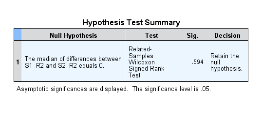